# Assignment 9

### Grad school admissions based on GPA, GRE, and institution rank

I will examine the `GradSchool_Admissions.csv` dataset to determine whether GPA, GRE score, and undergraduate institution rank predict graduate school admission.

Setup:

```r
library(tidyverse)
```

Let’s have a look how the data is structured:

```r
admissions <- read.csv("GradSchool_Admissions.csv")
admissions$rank <- factor(admissions$rank)

str(admissions)
```

```
## 'data.frame':    400 obs. of  4 variables:
##  $ admit: int  0 1 1 1 0 1 1 0 1 0 ...
##  $ gre  : int  380 660 800 640 520 760 560 400 540 700 ...
##  $ gpa  : num  3.61 3.67 4 3.19 2.93 3 2.98 3.08 3.39 3.92 ...
##  $ rank : Factor w/ 4 levels "1","2","3","4": 3 3 1 4 4 2 1 2 3 2 ...
```

```r
summary(admissions)
```

```
##      admit             gre             gpa        rank
##  Min.   :0.0000   Min.   :220.0   Min.   :2.260   1: 61
##  1st Qu.:0.0000   1st Qu.:520.0   1st Qu.:3.130   2:151
##  Median :0.0000   Median :580.0   Median :3.395   3:121
##  Mean   :0.3175   Mean   :587.7   Mean   :3.390   4: 67
##  3rd Qu.:1.0000   3rd Qu.:660.0   3rd Qu.:3.670
##  Max.   :1.0000   Max.   :800.0   Max.   :4.000
```

The dataset contains 400 observations and 4 variables: admission outcome, GRE score, GPA, and undergraduate institution rank. Because `admit` is binary, I will use a logistic regression model.

Next, I will explore how admission varies with undergraduate institution rank.

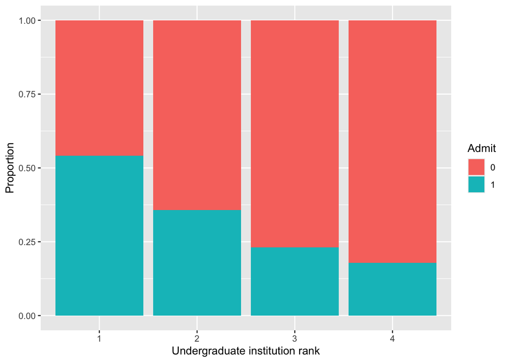

```r
ggplot(admissions, aes(x = rank, fill = factor(admit))) +
  geom_bar(position = "fill") +
  labs(x = "Undergraduate institution rank",
       y = "Proportion",
       fill = "Admit")
```

This plot suggests that students from higher-ranked institutions have a higher proportion of admission compared to those from lower-ranked institutions.

I will also compare GRE score distributions between admitted and non-admitted students.

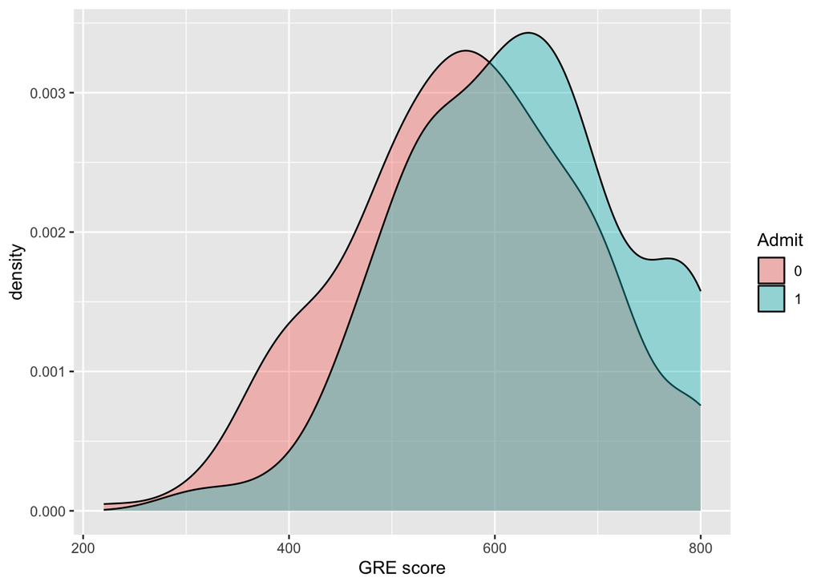

```r
ggplot(admissions, aes(x = gre, fill = factor(admit))) +
  geom_density(alpha = 0.4) +
  labs(x = "GRE score",
       fill = "Admit")
```

This plot suggests that admitted students tend to have higher GRE scores than students who weren’t admitted.

Now I will compare GPA distributions between admitted and non-admitted students.

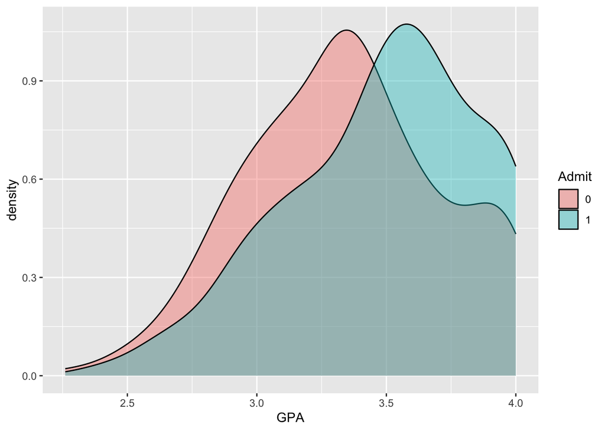

```r
ggplot(admissions, aes(x = gpa, fill = factor(admit))) +
  geom_density(alpha = 0.4) +
  labs(x = "GPA",
       fill = "Admit")
```

This plot suggests that admitted students tend to have higher GPAs than non-admitted students.

Based on these exploratory plots, GRE score, GPA, and undergraduate institution rank all appear to influence admission, so I will fit several logistic regression models.

```r
mod_gpa <- glm(admit ~ gpa, data = admissions, family = binomial)
mod_gre_gpa <- glm(admit ~ gre + gpa, data = admissions, family = binomial)
model_full <- glm(admit ~ gre + gpa + rank, data = admissions, family = binomial)
```

I will compare these models using AIC, where lower values indicate a better balance of model fit and complexity.

```r
AIC(mod_gpa, mod_gre_gpa, model_full)
```

```
##             df      AIC
## mod_gpa      2 490.9676
## mod_gre_gpa  3 486.3440
## model_full   6 470.5175
```

The full model had the lowest AIC value, indicating that including GRE score, GPA, and undergraduate institution rank provides the best fit among the models considered.

Now I will examine the full model in more detail.

```r
summary(model_full)
```

```
##
## Call:
## glm(formula = admit ~ gre + gpa + rank, family = binomial, data = admissions)
##
## Coefficients:
##              Estimate Std. Error z value Pr(>|z|)
## (Intercept) -3.989979   1.139951  -3.500 0.000465 ***
## gre          0.002264   0.001094   2.070 0.038465 *
## gpa          0.804038   0.331819   2.423 0.015388 *
## rank2       -0.675443   0.316490  -2.134 0.032829 *
## rank3       -1.340204   0.345306  -3.881 0.000104 ***
## rank4       -1.551464   0.417832  -3.713 0.000205 ***
## ---
## Signif. codes:  0 '***' 0.001 '**' 0.01 '*' 0.05 '.' 0.1 ' ' 1
##
## (Dispersion parameter for binomial family taken to be 1)
##
##     Null deviance: 499.98  on 399  degrees of freedom
## Residual deviance: 458.52  on 394  degrees of freedom
## AIC: 470.52
##
## Number of Fisher Scoring iterations: 4
```

The full model showed that GRE score and GPA were both significant positive predictors of admission. This indicates that students with higher GRE scores and higher GPAs had greater odds of being admitted.

Undergraduate institution rank was also an important predictor. Compared with students from rank 1 institutions, students from ranks 2, 3, and 4 had lower odds of admission. The negative coefficients for these levels indicate that lower-ranked institutions were associated with reduced admission odds.

Overall, the results suggest that both academic performance and undergraduate institution rank contribute meaningfully to graduate school admission outcomes.

### Conclusion

This analysis used logistic regression to model graduate school admission based on GRE score, GPA, and undergraduate institution rank. The results indicate that higher GRE scores, higher GPAs, and attending a higher-ranked undergraduate institution are all associated with a greater likelihood of admission.